# Tratamiento datos COVID-19 México 18/04/2020

Viacheslav Shalisko

18/4/2020

### Datos fuente

datos abiertos SSA https://www.gob.mx/salud/documentos/datos-abiertos-152127

### Fuentes auxiliares

Diccionarios de datos SSA https://www.gob.mx/salud/documentos/datos-abiertos-152127 y Catálogo Único de Claves de Áreas Geoestadísticas Estatales, Municipales y Localidades de INEGI https://www.inegi.org.mx/app/ageeml/

## Total de casos positivos

### Total de casos registrados para 18 de abril del 2020: 7497; aumento: 622.

## Resumen de registros positivos por estado

Tabla. Casos confirmados por estado para 18 de abril del 2020

| ID | Estado | Total de casos confirmados | Casos para ayer | Aumento de casos | Casos por 100k habitantes |
| --- | --- | --- | --- | --- | --- |
| 1 | AGUASCALIENTES | 77 | 77 | 0 | 6.5 |
| 2 | BAJA CALIFORNIA | 608 | 534 | 74 | 19.3 |
| 3 | BAJA CALIFORNIA SUR | 173 | 169 | 4 | 27.2 |
| 4 | CAMPECHE | 37 | 29 | 8 | 4.5 |
| 7 | CHIAPAS | 64 | 60 | 4 | 1.3 |
| 8 | CHIHUAHUA | 130 | 114 | 16 | 3.8 |
| 9 | CIUDAD DE MÉXICO | 1984 | 1804 | 180 | 22.4 |
| 5 | COAHUILA DE ZARAGOZA | 238 | 223 | 15 | 8.7 |
| 6 | COLIMA | 11 | 10 | 1 | 1.7 |
| 10 | DURANGO | 20 | 20 | 0 | 1.2 |
| 11 | GUANAJUATO | 118 | 114 | 4 | 2.2 |
| 12 | GUERRERO | 112 | 112 | 0 | 3.3 |
| 13 | HIDALGO | 80 | 75 | 5 | 3.0 |
| 14 | JALISCO | 195 | 189 | 6 | 2.7 |
| 15 | MÉXICO | 1071 | 1002 | 69 | 7.1 |
| 16 | MICHOACÁN DE OCAMPO | 108 | 100 | 8 | 2.5 |
| 17 | MORELOS | 86 | 81 | 5 | 4.8 |
| 18 | NAYARIT | 37 | 35 | 2 | 3.4 |
| 19 | NUEVO LEÓN | 169 | 156 | 13 | 3.6 |
| 20 | OAXACA | 63 | 57 | 6 | 1.7 |
| 21 | PUEBLA | 331 | 315 | 16 | 5.7 |
| 22 | QUERÉTARO | 79 | 77 | 2 | 4.3 |
| 23 | QUINTANA ROO | 317 | 282 | 35 | 23.9 |
| 24 | SAN LUIS POTOSÍ | 58 | 57 | 1 | 2.2 |
| 25 | SINALOA | 411 | 372 | 39 | 14.8 |
| 26 | SONORA | 112 | 101 | 11 | 4.2 |
| 27 | TABASCO | 283 | 255 | 28 | 12.6 |
| 28 | TAMAULIPAS | 119 | 95 | 24 | 3.6 |
| 29 | TLAXCALA | 67 | 62 | 5 | 5.7 |
| 30 | VERACRUZ DE IGNACIO DE LA LLAVE | 135 | 130 | 5 | 1.8 |
| 31 | YUCATÁN | 177 | 145 | 32 | 9.1 |
| 32 | ZACATECAS | 27 | 23 | 4 | 1.8 |

# Histogramas de registros positivos por estado

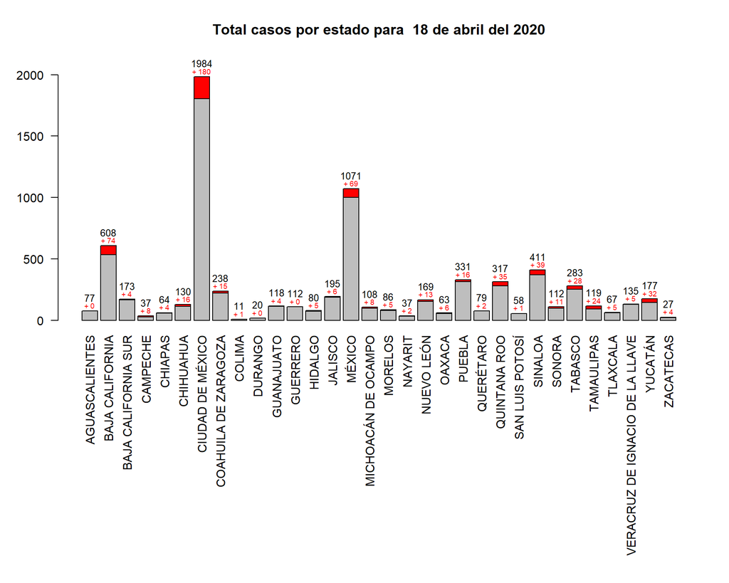

# Histogramas de registros positivos por estado (2)

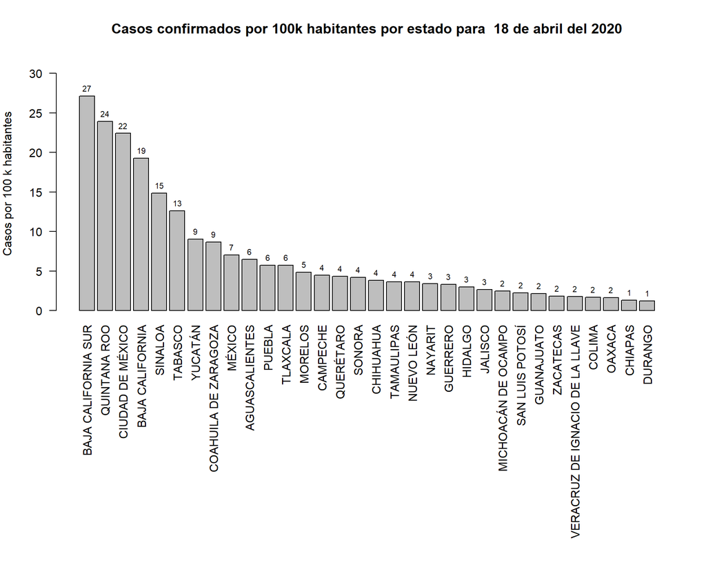

# Total de defunciones

### Total de defunciones registrados para 18 de abril del 2020: 650; aumento: 104.

## Resumen de defunciones por estado

Tabla. Defunciones por estado para 18 de abril del 2020

| ID | Estado | Total de defunciones | Defunciones para ayer | Aumento |
| --- | --- | --- | --- | --- |
| 1 | AGUASCALIENTES | 2 | 2 | 0 |
| 2 | BAJA CALIFORNIA | 67 | 32 | 35 |
| 3 | BAJA CALIFORNIA SUR | 6 | 6 | 0 |
| 4 | CAMPECHE | 2 | 2 | 0 |
| 7 | CHIAPAS | 3 | 3 | 0 |
| 8 | CHIHUAHUA | 30 | 26 | 4 |
| 9 | CIUDAD DE MÉXICO | 161 | 126 | 35 |
| 5 | COAHUILA DE ZARAGOZA | 19 | 16 | 3 |
| 6 | COLIMA | 2 | 2 | 0 |
| 10 | DURANGO | 4 | 4 | 0 |
| 11 | GUANAJUATO | 9 | 7 | 2 |
| 12 | GUERRERO | 11 | 11 | 0 |
| 13 | HIDALGO | 12 | 11 | 1 |
| 14 | JALISCO | 13 | 13 | 0 |
| 15 | MÉXICO | 69 | 60 | 9 |
| 16 | MICHOACÁN DE OCAMPO | 16 | 14 | 2 |
| 17 | MORELOS | 11 | 10 | 1 |
| 18 | NAYARIT | 5 | 5 | 0 |
| 19 | NUEVO LEÓN | 5 | 4 | 1 |
| 20 | OAXACA | 6 | 4 | 2 |
| 21 | PUEBLA | 42 | 39 | 3 |
| 22 | QUERÉTARO | 6 | 6 | 0 |
| 23 | QUINTANA ROO | 31 | 31 | 0 |
| 24 | SAN LUIS POTOSÍ | 4 | 4 | 0 |
| 25 | SINALOA | 45 | 43 | 2 |
| 26 | SONORA | 11 | 11 | 0 |
| 27 | TABASCO | 29 | 28 | 1 |
| 28 | TAMAULIPAS | 5 | 5 | 0 |
| 29 | TLAXCALA | 4 | 4 | 0 |
| 30 | VERACRUZ DE IGNACIO DE LA LLAVE | 8 | 7 | 1 |
| 31 | YUCATÁN | 10 | 8 | 2 |
| 32 | ZACATECAS | 2 | 2 | 0 |

# Histogramas de defunciones por estado

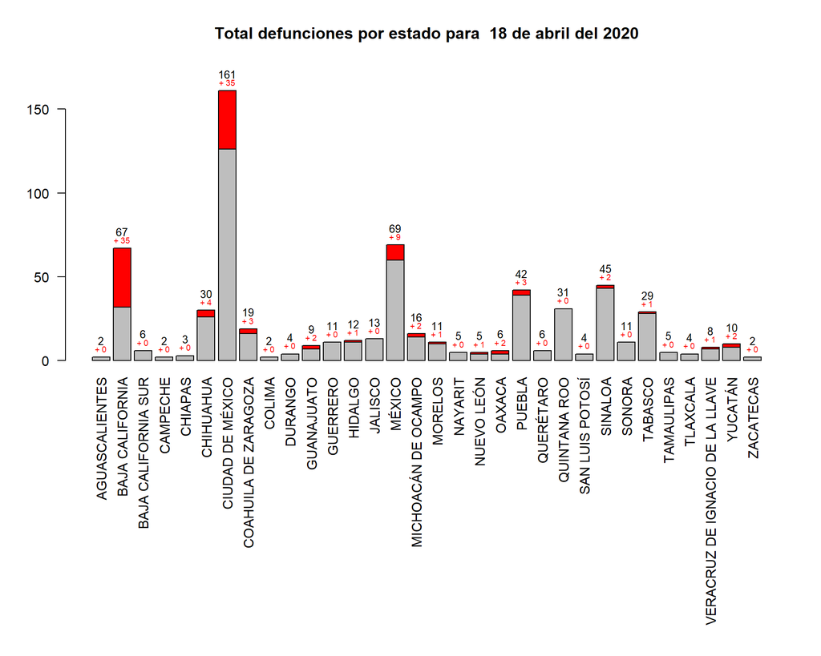

# Total de pruebas realizadas

### Total de pruebas con resultado negativo registrados para 18 de abril del 2020: 29301; aumento: 1175.

### Total de pruebas con resultado para 18 de abril del 2020: 36798; aumento: 1797

## Resumen de pruebas por estado

Tabla. Pruebas por estado para 18 de abril del 2020

| ID | Estado | Total de pruebas negativas | Nuevos negativos | Total de pruebas positivas | Nuevos positivos | Total de pruebas | Pruebas nuevas | % de positiovs | % de positivos en pruebas nuevas | Pruebas por 100k habitantes |
| --- | --- | --- | --- | --- | --- | --- | --- | --- | --- | --- |
| 1 | AGUASCALIENTES | 828 | 12 | 77 | 0 | 905 | 12 | 8.51 | 0.00 | 83.29 |
| 2 | BAJA CALIFORNIA | 855 | 22 | 608 | 74 | 1463 | 96 | 41.56 | 43.53 | 72.45 |
| 3 | BAJA CALIFORNIA SUR | 523 | 4 | 173 | 4 | 696 | 8 | 24.86 | 33.33 | 158.39 |
| 4 | CAMPECHE | 133 | 9 | 37 | 8 | 170 | 17 | 21.76 | 32.00 | 23.71 |
| 7 | CHIAPAS | 294 | 16 | 64 | 4 | 358 | 20 | 17.88 | 16.67 | 8.65 |
| 8 | CHIHUAHUA | 322 | 38 | 130 | 16 | 452 | 54 | 28.76 | 22.86 | 19.64 |
| 9 | CIUDAD DE MÉXICO | 5360 | 310 | 1984 | 180 | 7344 | 490 | 27.02 | 26.87 | 105.66 |
| 5 | COAHUILA DE ZARAGOZA | 1263 | 34 | 238 | 15 | 1501 | 49 | 15.86 | 23.44 | 89.76 |
| 6 | COLIMA | 103 | 2 | 11 | 1 | 114 | 3 | 9.65 | 25.00 | 20.75 |
| 10 | DURANGO | 285 | 6 | 20 | 0 | 305 | 6 | 6.56 | 0.00 | 24.80 |
| 11 | GUANAJUATO | 1762 | 29 | 118 | 4 | 1880 | 33 | 6.28 | 10.81 | 40.54 |
| 12 | GUERRERO | 346 | 5 | 112 | 0 | 458 | 5 | 24.45 | 0.00 | 17.17 |
| 13 | HIDALGO | 411 | 6 | 80 | 5 | 491 | 11 | 16.29 | 31.25 | 20.71 |
| 14 | JALISCO | 2652 | 66 | 195 | 6 | 2847 | 72 | 6.85 | 7.69 | 45.89 |
| 15 | MÉXICO | 2740 | 95 | 1071 | 69 | 3811 | 164 | 28.10 | 29.61 | 35.87 |
| 16 | MICHOACÁN DE OCAMPO | 646 | 55 | 108 | 8 | 754 | 63 | 14.32 | 11.27 | 23.12 |
| 17 | MORELOS | 342 | 11 | 86 | 5 | 428 | 16 | 20.09 | 23.81 | 27.68 |
| 18 | NAYARIT | 205 | 5 | 37 | 2 | 242 | 7 | 15.29 | 22.22 | 26.91 |
| 19 | NUEVO LEÓN | 2179 | 97 | 169 | 13 | 2348 | 110 | 7.20 | 10.57 | 97.02 |
| 20 | OAXACA | 373 | 9 | 63 | 6 | 436 | 15 | 14.45 | 28.57 | 13.15 |
| 21 | PUEBLA | 910 | 20 | 331 | 16 | 1241 | 36 | 26.67 | 30.77 | 27.46 |
| 22 | QUERÉTARO | 460 | 11 | 79 | 2 | 539 | 13 | 14.66 | 13.33 | 33.64 |
| 23 | QUINTANA ROO | 453 | 20 | 317 | 35 | 770 | 55 | 41.17 | 38.89 | 72.65 |
| 24 | SAN LUIS POTOSÍ | 948 | 23 | 58 | 1 | 1006 | 24 | 5.77 | 4.00 | 42.89 |
| 25 | SINALOA | 811 | 31 | 411 | 39 | 1222 | 70 | 33.63 | 35.78 | 54.38 |
| 26 | SONORA | 559 | 15 | 112 | 11 | 671 | 26 | 16.69 | 29.73 | 31.29 |
| 27 | TABASCO | 523 | 11 | 283 | 28 | 806 | 39 | 35.11 | 41.79 | 52.04 |
| 28 | TAMAULIPAS | 708 | 85 | 119 | 24 | 827 | 109 | 14.39 | 18.05 | 32.15 |
| 29 | TLAXCALA | 416 | 17 | 67 | 5 | 483 | 22 | 13.87 | 18.52 | 48.72 |
| 30 | VERACRUZ DE IGNACIO DE LA LLAVE | 943 | 6 | 135 | 5 | 1078 | 11 | 12.52 | 31.25 | 20.44 |
| 31 | YUCATÁN | 639 | 88 | 177 | 32 | 816 | 120 | 21.69 | 21.05 | 47.04 |
| 32 | ZACATECAS | 309 | 17 | 27 | 4 | 336 | 21 | 8.04 | 16.00 | 26.03 |

# Histogramas de pruebas por estado

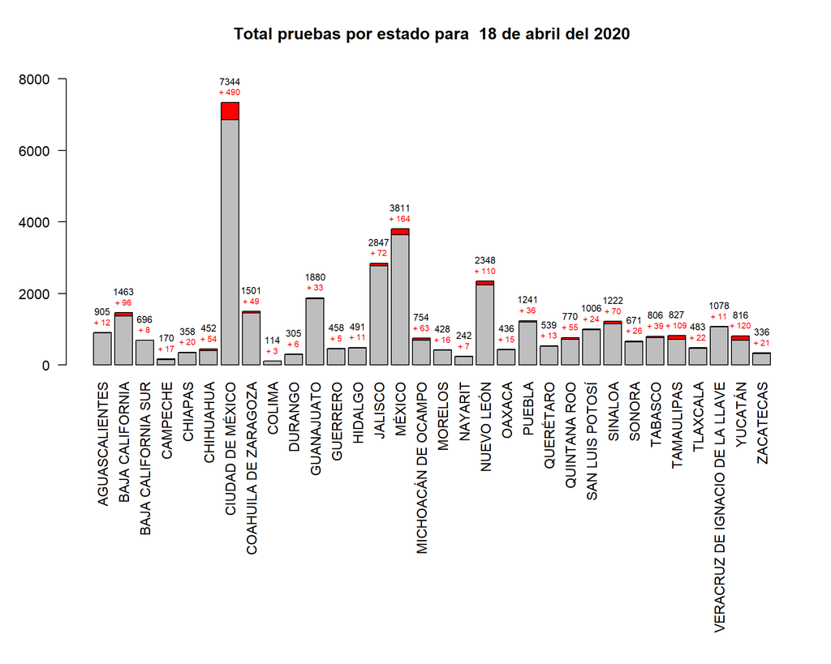

# Histogramas de pruebas por estado (2)

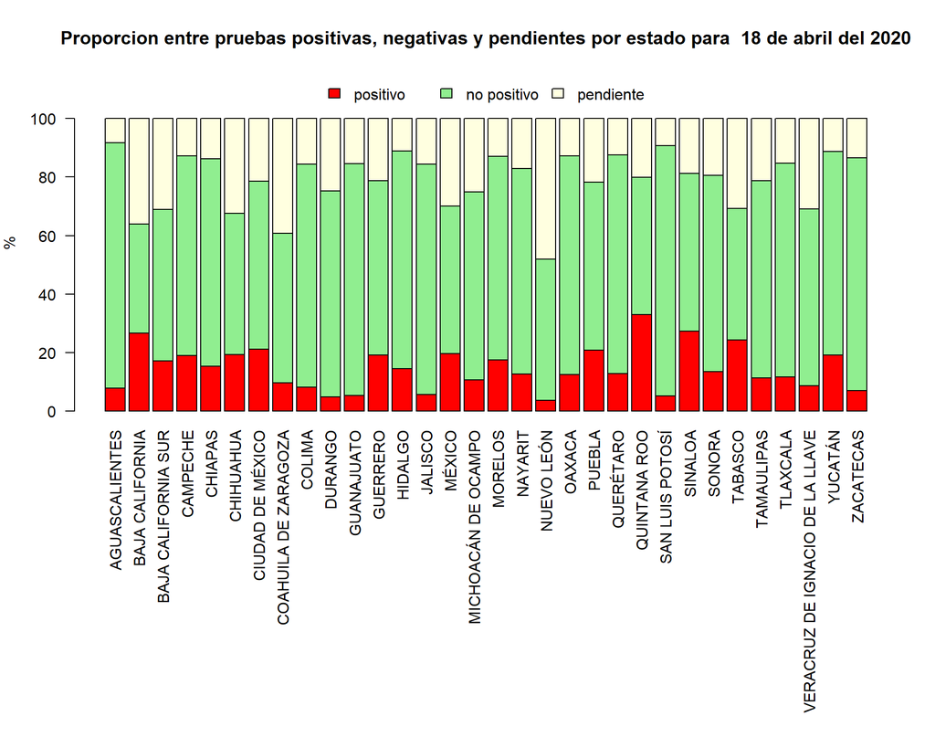

# Histogramas de pruebas por estado (3)

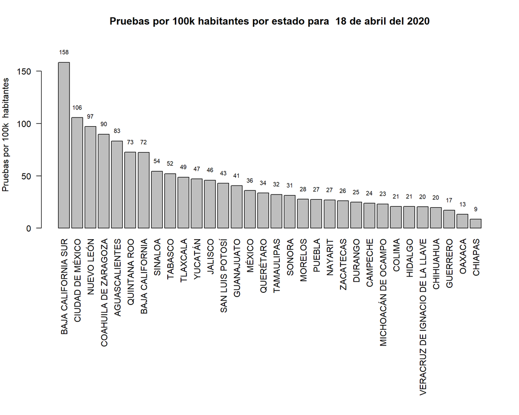

# Relación entre número de casos confirmados y numero de pruebas por estados de México

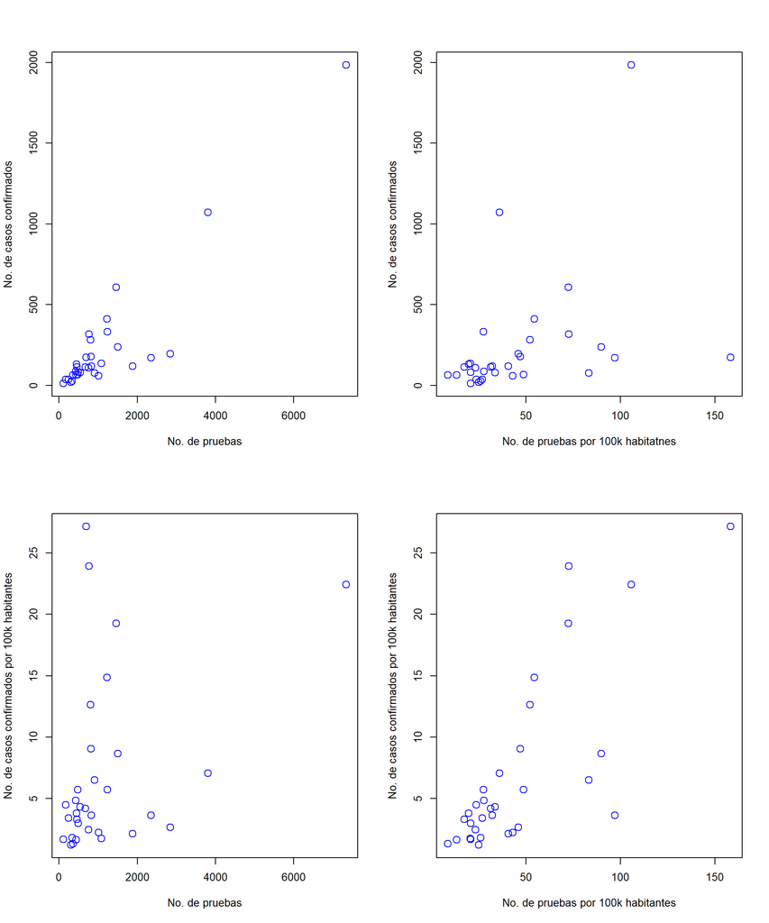

# Relación entre número de casos, numero de pruebas y porcentaje de pruebas positivas por estados de México

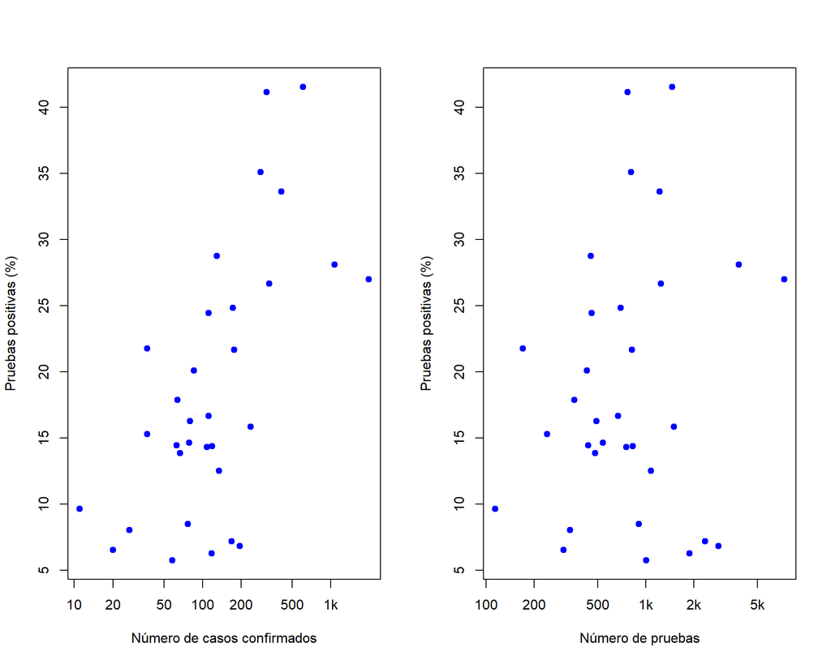

# Tabla de registros positivos por municipio

Tabla. Los cien municipios con mayór incidencia para 18 de abril del 2020

| Casos confirmados | Aumento casos | Casos por 100k habitantes | Defunciones | Aumento def. | Pruebas negativas | % de pruebas positivas | Pruebas por 100k habitantes | Localidad | Municipio | Estado |
| --- | --- | --- | --- | --- | --- | --- | --- | --- | --- | --- |
| 343 | 49 | 25.5 | 41 | 22 | 369 | 48.2 | 87.6 | Tijuana | TIJUANA | BC |
| 303 | 19 | 35.3 | 30 | 1 | 413 | 42.3 | 104.9 | Culiacán Rosales | CULIACÁN | SL |
| 280 | 25 | 15.4 | 28 | 5 | 611 | 31.4 | 66.5 | Iztapalapa | IZTAPALAPA | DF |
| 238 | 30 | 20.1 | 38 | 14 | 563 | 29.7 | 92.3 | Gustavo A. Madero | GUSTAVO A. MADERO | DF |
| 230 | 16 | 26.6 | 19 | 10 | 296 | 43.7 | 93.5 | Mexicali | MEXICALI | BC |
| 224 | 22 | 34.7 | 15 | 0 | 258 | 46.5 | 96.6 | Cancún | BENITO JUÁREZ | QR |
| 209 | 10 | 13.6 | 26 | 4 | 520 | 28.7 | 60.8 | Heroica Puebla de Zaragoza | PUEBLA | PL |
| 189 | 23 | 29.5 | 17 | 1 | 383 | 33.0 | 113.1 | Villahermosa | CENTRO | TC |
| 186 | 30 | 28.6 | 8 | 1 | 419 | 30.7 | 113.7 | Tlalpan | TLALPAN | DF |
| 171 | 11 | 45.9 | 6 | 2 | 364 | 32.0 | 159.8 | Miguel Hidalgo | MIGUEL HIDALGO | DF |
| 163 | 17 | 22.4 | 15 | 1 | 438 | 27.1 | 102.8 | Álvaro Obregón | ÁLVARO OBREGÓN | DF |
| 148 | 29 | 17.9 | 5 | 1 | 502 | 22.8 | 88.3 | Mérida | MÉRIDA | YN |
| 139 | 5 | 26.1 | 12 | 1 | 379 | 26.8 | 121.8 | Cuauhtémoc | CUAUHTÉMOC | DF |
| 128 | 11 | 11.5 | 11 | 2 | 273 | 31.9 | 54.6 | Ciudad Nezahualcóyotl | NEZAHUALCÓYOTL | MC |
| 123 | 10 | 56.9 | 11 | 2 | 286 | 30.1 | 294.0 | Monclova | MONCLOVA | CL |
| 123 | 10 | 19.8 | 8 | 2 | 366 | 25.2 | 99.1 | Coyoacán | COYOACÁN | DF |
| 123 | 15 | 7.4 | 6 | 3 | 292 | 29.6 | 35.2 | Ecatepec de Morelos | ECATEPEC DE MORELOS | MC |
| 120 | 3 | 80.3 | 2 | 0 | 247 | 32.7 | 346.6 | San José del Cabo | LOS CABOS | BS |
| 101 | 5 | 54.2 | 3 | 2 | 165 | 38.0 | 161.5 | Cuajimalpa de Morelos | CUAJIMALPA DE MORELOS | DF |
| 96 | 5 | 24.9 | 5 | 2 | 434 | 18.1 | 160.1 | Benito Juárez | BENITO JUÁREZ | DF |
| 94 | 8 | 22.7 | 7 | 2 | 284 | 24.9 | 115.5 | Azcapotzalco | AZCAPOTZALCO | DF |
| 93 | 10 | 22.5 | 8 | 0 | 313 | 22.9 | 126.3 | Xochimilco | XOCHIMILCO | DF |
| 93 | 7 | 21.6 | 10 | 2 | 239 | 28.0 | 97.0 | Venustiano Carranza | VENUSTIANO CARRANZA | DF |
| 89 | 3 | 10.7 | 4 | 0 | 264 | 25.2 | 57.1 | Naucalpan de Juárez | NAUCALPAN DE JUÁREZ | MC |
| 88 | 13 | 6.6 | 24 | 2 | 157 | 35.9 | 28.8 | Juárez | JUÁREZ | CH |
| 85 | 3 | 12.8 | 1 | 0 | 209 | 28.9 | 62.2 | Tlalnepantla | TLALNEPANTLA DE BAZ | MC |
| 83 | 7 | 21.6 | 5 | 0 | 222 | 27.2 | 110.1 | Iztacalco | IZTACALCO | DF |
| 69 | 1 | 4.6 | 4 | 0 | 754 | 8.4 | 64.7 | Guadalajara | GUADALAJARA | JC |
| 66 | 0 | 8.4 | 2 | 0 | 654 | 9.2 | 99.5 | Aguascalientes | AGUASCALIENTES | AS |
| 64 | 2 | 8.3 | 5 | 0 | 301 | 17.5 | 55.3 | Santiago de Querétaro | QUERÉTARO | QT |

[output cut: 70 more lines]

# Relación entre número de casos confirmados y numero de pruebas por municipios de México (ejes lineales)

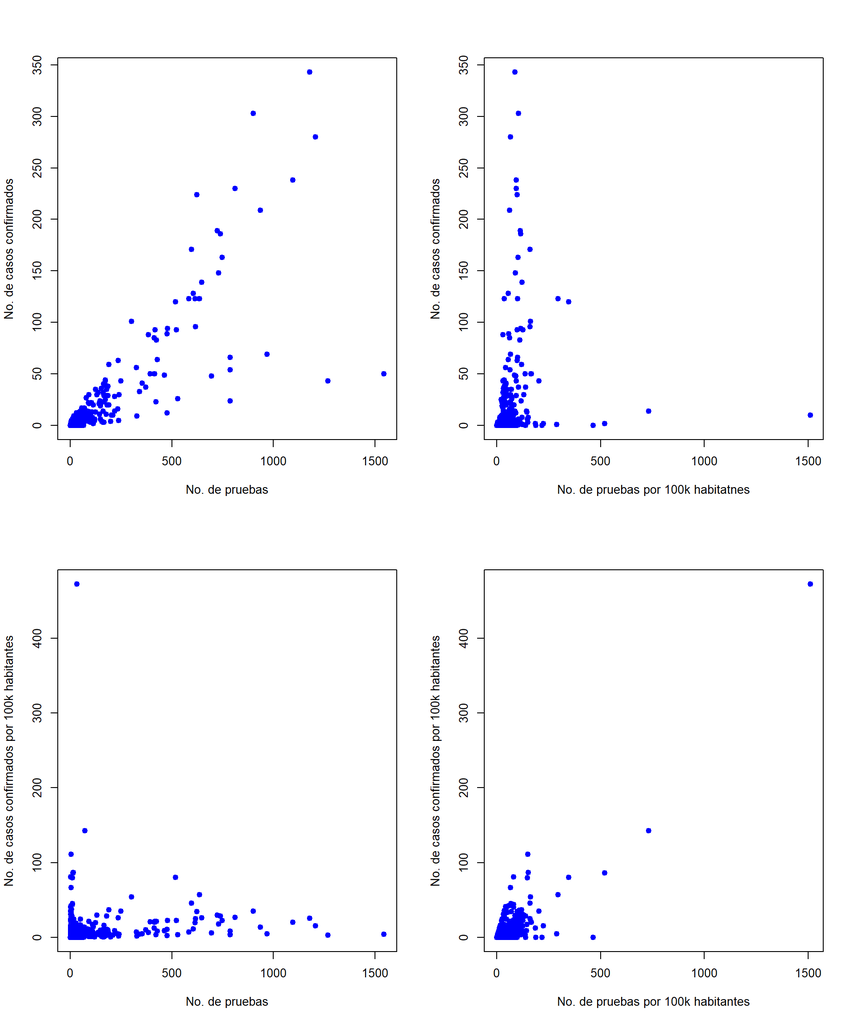

# Relación entre número de casos confirmados y numero de pruebas por municipios de México (ejes logaritmicos)

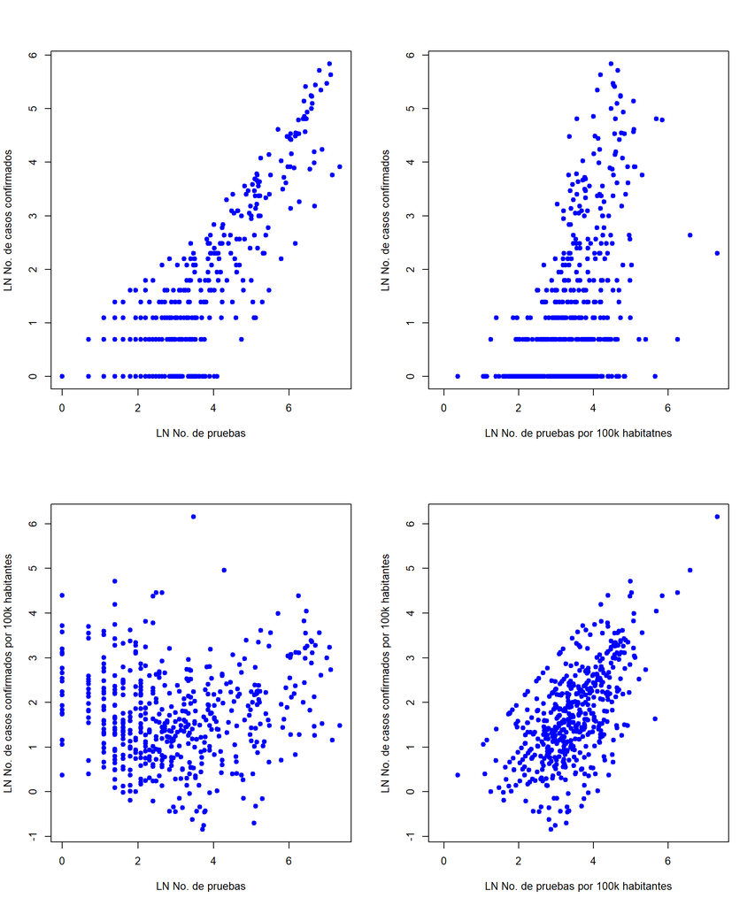

# Relación entre número de casos, numero de pruebas y porcentaje de pruebas positivas por municipios de México

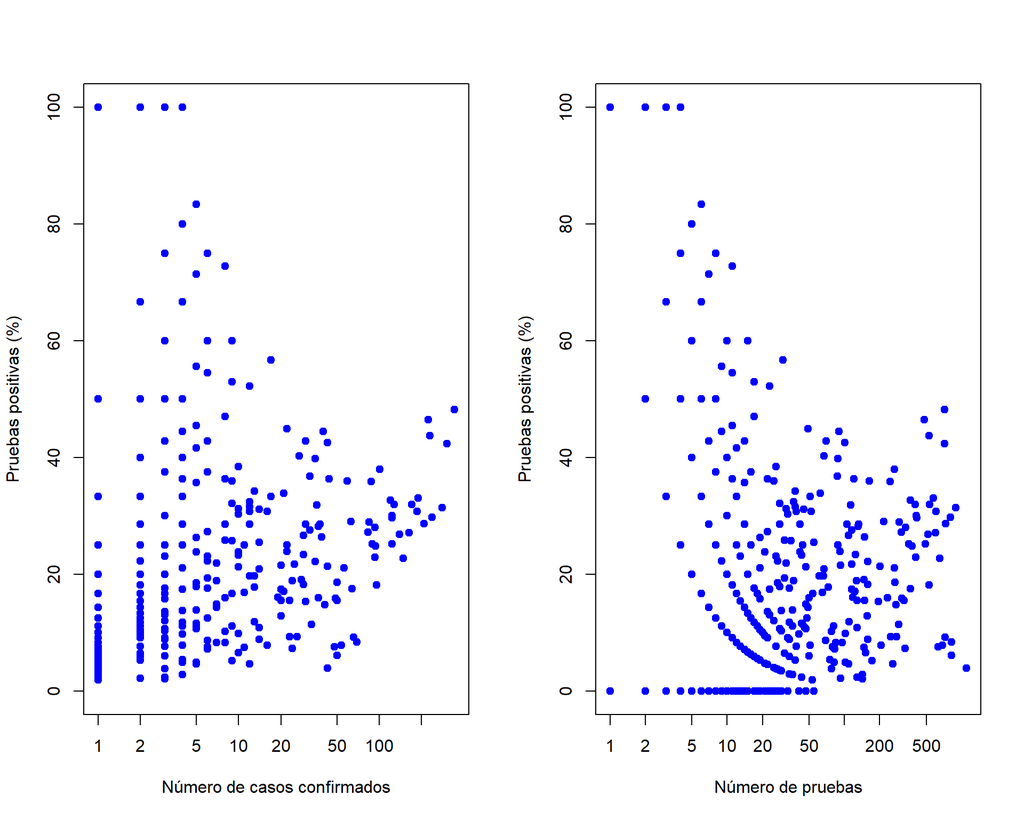

# Mapa de pruebas: número de pruebas para COVID-19 y % de positividad por municipio para 18 de abril del 2020

[interactive chart not shown]

# Mapa de casos confirmados de COVID-19 por municipio para 18 de abril del 2020

[interactive chart not shown]

# Mapa de defunciones por COVID-19 por municipio para 18 de abril del 2020

[interactive chart not shown]